# R Parallel computing

3 octobre 2019

## Le processeur

- Est le composant du PC qui effectue les calculs et instructions
- Il est divisé en coeurs (core)
- un coeur ne peut traiter q'une instruction à la fois
- R utilise par défaut qu'un coeur
- Utiliser plusieurs coeurs peut augmenter la vitesse de calcul

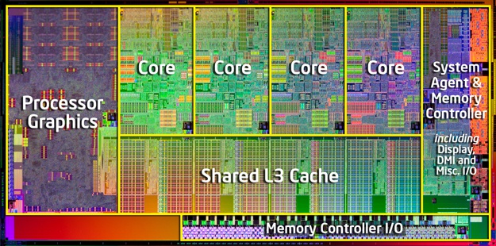

circuit integré du i7-2600k

## La parallélisation

- Est un moyen efficace mais situationnel de reduire le temps de calcul
- Repose sur deux packages

```r
library(foreach)
library(doParallel)
```

## Boucle foreach

Légèrement différente de la boucle `for` classique. Utilisable sans paralléliser avec l'opérateur `%do%`.

```r
x <- foreach(i = 1:3) %do% sqrt(i)
x
```

```
## [[1]]
## [1] 1
##
## [[2]]
## [1] 1.414214
##
## [[3]]
## [1] 1.732051
```

## Boucle foreach

Contrairement à `for` retourne des résultats, stockés par défaut dans une liste.

Possibilité de changer la façon dont les résultats sont assemblés en passant une fonction à `.combine` :

```r
x <- foreach(a = 1:3, b = rep(10,3), .combine = c) %do% (a + b)
x
```

```
## [1] 11 12 13
```

Remarque : on peut itérer plusieurs variables comme un mapply

## Boucle foreach

Retourner un data frame :

```r
x <- foreach(m = c(5,10,15), sdev = 1:3, .combine = cbind) %do% {
  rnorm(4, m, sdev)
}
x
```

```
##      result.1  result.2 result.3
## [1,] 4.792405  7.504957 18.58157
## [2,] 4.345148 12.036047 15.45004
## [3,] 6.667795  7.251067 12.42775
## [4,] 6.569295 12.995585 16.19284
```

Autre subtilité: il faut spécifier les packages utilisés au sein de la boucle avec l'argument `.package=`

## Doparallel

*Obtenir le nombre de coeurs de la machine*

```r
nbcoeur <- detectCores() # intel i5 : 4 coeurs
```

*Il faut tout d'abord lancer une session de R par coeur*

```r
clust <- makeCluster(nbcoeur-1) # recommandé
```

*Et que ces autres sessions soient detectées par foreach*

```r
registerDoParallel(clust)
```

*Renvoie le nombre de coeur qui seront utilisés*

```r
getDoParWorkers()
```

```
## [1] 3
```

*Stopper le clustering*

```r
stopCluster(clust)
```

## %dopar%

Pour paralléliser: remplacer `%do%` par `%dopar%`

## Parallélisation efficace

*Efficace si:*

- l'opération à répéter est longue (opération à droite de `%dopar%` est longue à calculer)
- le nombre d'itération est un multiple du nombre de coeurs utilisés

```r
foreach(i=(petit ou grand vecteur))%dopar%{Gros modèle enervé}
foreach(i=1:3,) %dopar%{glm(NDVI~PP+TEMP,datanasa[[i]],
                                  family=binomial(logit))}
```

```r
formula1=formula(NDVI~PP)
formula2=formula(NDVI~PP*TEMP)
formula3=formula(NDVI~PP*TEMP + SNOW)
listform=list(formula1,formula2,formula3)
foreach(F=listform) %dopar%{glm(F,datanasa[[i]],
                                  family=binomial(logit))}
```

## Parallélisation

*Contre productif si:*

- le temps de calcul est déja court
- le calcul est long à cause d'un grand nombre d'itérations de la boucle, mais qu'une seule itération est très rapide à calculer

```r
foreach(i=1:GROSNOMBRE,.combine = "c"){ Opération ultra rapide}

foreach(i=1:100000,.combine = "c"){ 1+i}
```

## Exemples

Inefficacité de la parallélisation

```r
res2 <- numeric()
dft <- data.frame(time_foreach = numeric(), time_for = numeric())
for (i in 1:20) {
  tfe <- system.time(
    res <- foreach(j = 1:1000, .combine = c) %dopar% sqrt(j)
    )[[3]]

  tf <- system.time(
    for(k in 1:1000){
      res2  <- c(res2, sqrt(k))
      }
    )[[3]]

  dft[i,] <- c(tfe, tf)
}
```

## Exemples

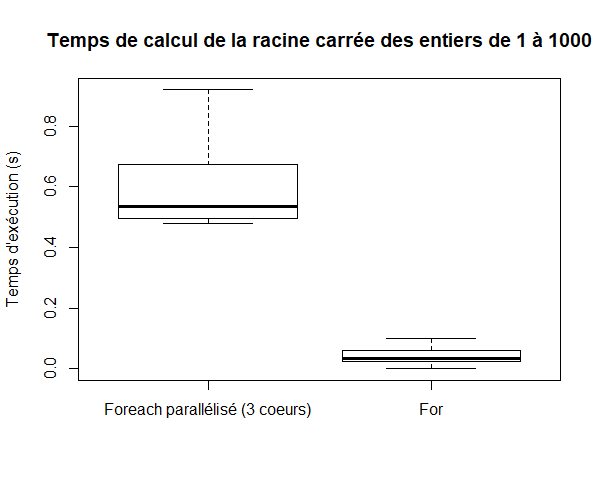

Parallélisation sur sqrt()

## Exemples

```r
r <- foreach(icount(n), .combine=cbind) %dopar% {
      ind <- sample(100, 100, replace=TRUE)
      result1 <- glm(x[ind,2]~x[ind,1], family=binomial(logit))}
```

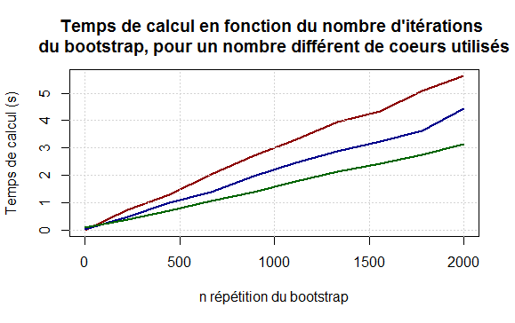

rouge: calcul séquentiel (1 coeur), bleu: 2 coeurs, vert: 4 coeurs

## Documentation

Commencer à utiliser `doParallel` et `foreach` https://cran.r-project.org/web/packages/doParallel/vignettes/gettingstartedParallel.pdf

`foreach` plus approfondi https://cran.r-project.org/web/packages/foreach/vignettes/foreach.pdf